# EDAV Fall 2019- Final Project

Foad Khoshouei- fk2377, Nima Chitsazan nc2806

```r
library(ggplot2)
library(dplyr)
library(tidyverse)
library(choroplethr)
library(rvest)
library(robotstxt)
library(XML)
library(xml2)
library(rvest)
library(ggmap)
```

**I.Introduction:**

Green taxis also known as boro taxis were introduced in August 2013 to improve taxi service and availability in New York City (https://www1.nyc.gov). The green taxis are allowed to pick-up passengers in the Bronx, Brooklyn, Queens (excluding JFK and LaGuardia Airports), Staten Island and in Manhattan above East 96th and West 110th Streets. The color of boro taxis is green in contrast to the traditional yellow cabs in NYC (Wikipedia).

NYC Taxi and Limousine Commission (TLC) has published reports about the background on the Boro Taxi program. It has been reported that according to the GPS data gathered from yellow cabs, 95% of the pick-ups occur in Manhattan below 96th Street and at JFK and LaGuardia. This resulted in very limited access to legal taxis in outer boroughs for the residents. The green taxi program was designed and implemented to improve mobility, passenger safety and to reduce illegal activity. According to TLC 2018 Annual Report, there are currently 3,566 licensed green cabs active in NYC compared to 13,587 yellow cabs.

In this project, we studied the data gathered by TLC on green taxis in 2018 to explore the distribution of pick-up and drop-offs to measure the effectiveness of the program. In addition we explored the relation between the trip distance and fare amount, percentage of tip compared to the fare amount and distribution of trip distances for green taxis.

**II.Data Source and Details**

The data is available from the NYC TLC website (https://www1.nyc.gov/site/tlc/about/tlc-trip-record-data.page) for green taxis for each month. We used the data for 2018 to work with as the most recent dataset for the full year available. In order to download the data, we prepared a separate R code for web scraping that directly downloads the data from the S3 buckets linked to the TLC website for each month (code available in Github repo) (https://github.com/fk2377/EDAV_final). In the next step, we concatenated the data and took a sub-sample of size 60,000 records (5000 per month) to have a workable data-frame. The resulting dataset was then saved and is loaded by our data exploration code.

The resulting data-frame is available on our Google drive: https://drive.google.com/open?id=1RQ-XAlLDNDdFRLQywgQk-IABEJEEzplP

The data is comprised of 25 different variables (columns), including pick-up date and time, trip distance, pick-up and drop-off location ID, fare amount, tip amount and payment type (credit card, cash,…). We investigated the details in the next section.

```r
#reading the data
load("sample_green_2018.Rda")
df<-total
```

**III.Data Cleaning**

Exploring the fare amount, the data ranges between -120 USD and 1230 USD. Since the fare amount can’t be negative, we have removed the negative fares from the dataset. Also, the fares are mostly in the range of 0-100$ and to better show the histogram of the data, we have removed the outliers of the data using a fence size of 1.5*(Q4-Q2) for the upper limit. The lower limit as discussed is zero.

Exploring the tip amounts, there are some higher values that are removed as outliers, using the same formula. We further explored the tip data to see patterns of how people tip. We noticed that the payment type is also providing us additional information. Whenever the payment type is cash, more than 99% of the time the tip amount reported is zero which seems to be questionable so we treated this as when payment is cash, the amount of tip is missing and values were replaced with NA to better capture the underlying nature of the data. But we kept all the original tip data for all other forms of payment (credit card, …) to explore tipping habits of green taxi riders. There was no missing value in dataset to start with, so there are no patterns from the data, but we introduced missing data for tips wherever payment type is cash (instead of having it at zero)

```r
#cleaning the data- removing negative fares and outliers from the fare data
#fence is 1.5 times q4-q2 plus q4
q<-quantile(df$fare_amount)
up=q[4]+1.5*(q[4]-q[2])
df<-df[!(df$fare_amount<=0 | df$fare_amount>up),]
```

```r
#removing outliers and negative tips
q<-quantile(df$tip_amount)
up=q[4]+1.5*(q[4]-q[2])
df<-df[!(df$tip_amount< 0 | df$tip_amount>up),]
```

```r
#replacing zero tips with NA for cash payments
df$tip_amount[df$tip_amount == 0 & df$payment_type!=1] <- NA
```

```r
df<- df %>%
          mutate(tip_percent = 100*tip_amount/fare_amount);
```

**IV.Results**

The green taxi fares are distributed mostly between $3 and $30 with a skewness to the right. Most of the fares are below $20 and the highest frequency seems to be around $5~$9.

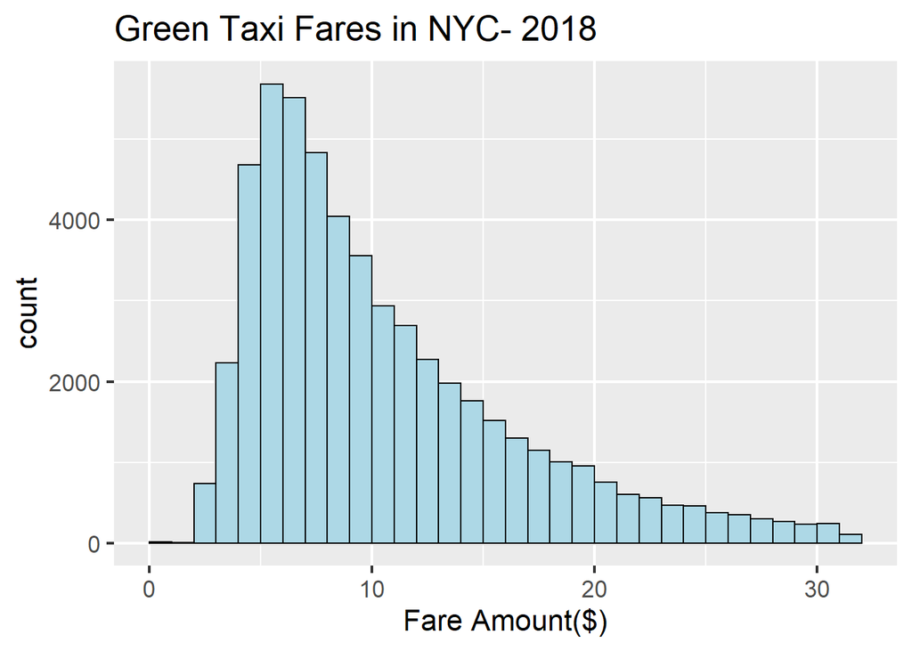

```r
ggplot(data = df) +
  geom_histogram(mapping = aes(fare_amount), fill='lightblue', binwidth = 1, color="black", boundary=0)+
  ggtitle("Green Taxi Fares in NYC- 2018")+
  labs(x = "Fare Amount($)") +
  theme(plot.title = element_text(face = "bold")) +
  theme(plot.title = element_text(hjust = 0.5))+
  theme_gray(16)
```

It is interesting to explore the distance of trips in NYC for green taxis. The data suggest that trips are mostly less than 12 miles. The fare amount has a linear relationship with distance, with a slope of about 2.5 ~ 4. So as a ballpark, the green cab fare can be calculated by the following formula. This is handy when someone is thinking to compare different transportation options:

Fare($) = 5 + (2.5~4) * Distance(miles)

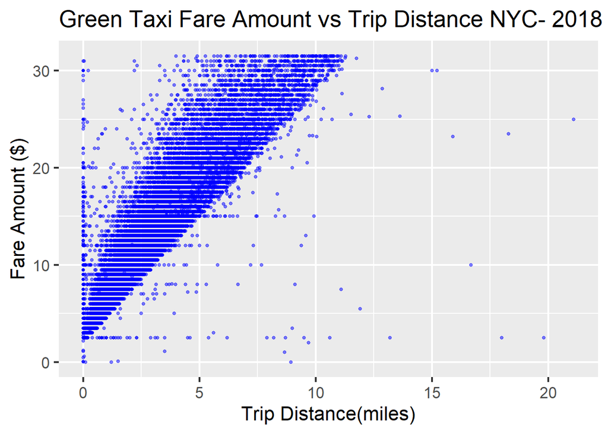

```r
ggplot(df, aes(trip_distance, fare_amount)) +
   geom_point(col="blue", size=1, alpha=0.5) +
  ggtitle("Green Taxi Fare Amount vs Trip Distance NYC- 2018")+
  labs(x = "Fare Amount($)", y="Tip Percent(%)")+
  theme(plot.title = element_text(face = "bold")) +
  theme(plot.title = element_text(hjust = 0.5))+
  xlab("Trip Distance(miles)")+
  ylab("Fare Amount ($)")+
  theme_gray(16)
```

Tipping is always a topic of discussion in media and news. (https://www.forbes.com/sites/garystoller/2018/01/19/to-tip-or-not-to-tip-or-how-much-to-tip-that-is-the-question/#b463ee9ff6cc.)

In many parts of the world including Europe, tipping is not required. In US, many service industries including restaurants, hotels and cabs rely on tips for their income. And there are always gray areas in between, like when you pick-up a coffee or take an Uber. In addition, NYC is a popular destination for tourists and 60 million people visit it per year. With that volume, a fraction of it might end up taking cabs and green taxis so it can create a different pattern in tipping. Also, people who live in NYC have different opinions about the amount of tip and it’s applicability to taxi rides. Here we clearly observe a bimodal pattern in the percentage of the tip. A big group of riders who use green cabs, do not pay any tips which is shown in graph below with about 30% of total rides observed. The next category with the highest frequency is about 20-25% tip which is an established norm and almost 35% of riders stick to that threshold.

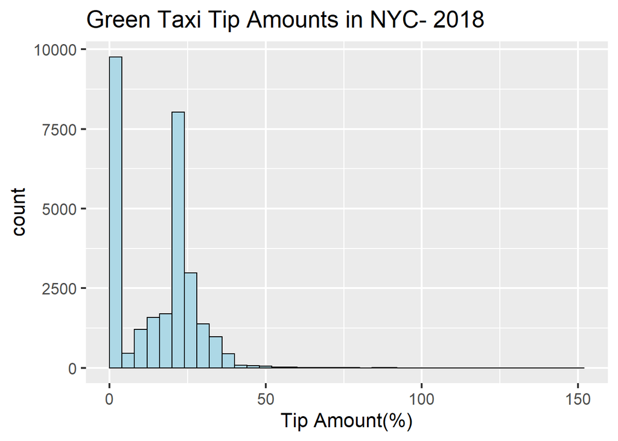

```r
ggplot(data = df) +
  geom_histogram(mapping = aes(tip_percent), fill='lightblue', binwidth = 4, color="black", boundary=0)+
  ggtitle("Green Taxi Tip Amounts in NYC- 2018")+
  labs(x = "Tip Amount(%)") +
  theme(plot.title = element_text(face = "bold")) +
  theme(plot.subtitle = element_text(face = "bold", color = "grey35")) +
  theme(plot.caption = element_text(color = "grey68"))+
  theme(plot.title = element_text(hjust = 0.5))+
  theme_gray(16)
```

Exploring the tip percentage as a function of fare amount, the percentage of tip decays as the fare amount increases and it settles at around 15% for the highest fares. This suggests that the riders that decide to tip, have a minimum dollar value in mind that are going to tip regardless of how short the trip or small the fare is. That is true for fares less than $5 where the tip is about 30-100% of the fare. As the fare amount increases, the percentage of tip gets closer to the 20-25% ratio and drops as the fare goes up. So as there is a minimum for the tip amount regardless of the fare, the contrary seems to be true as well and riders have a maximum amount in mind where they would adjust the percentage based on that.

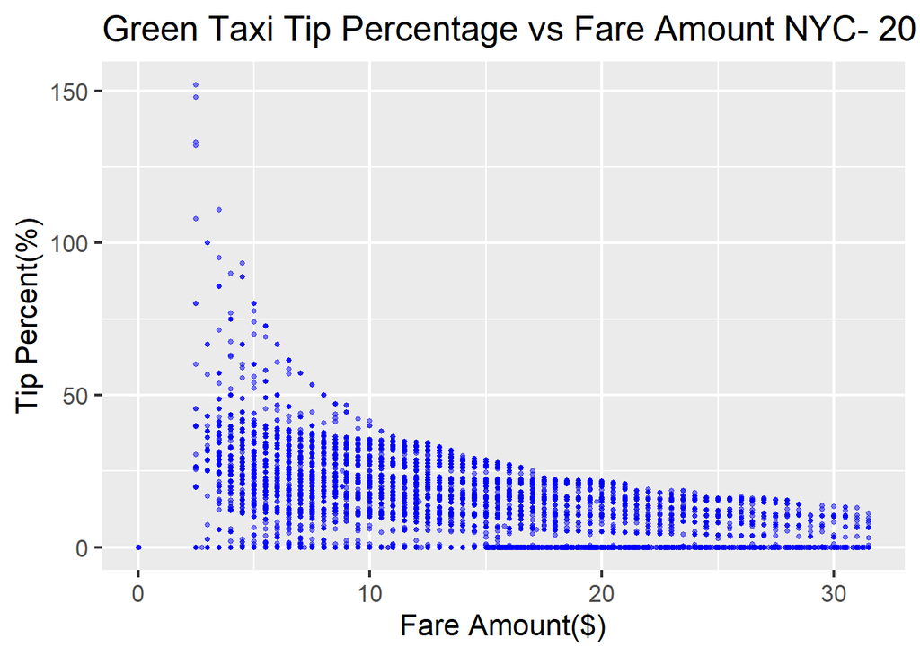

```r
ggplot(df, aes(fare_amount, tip_percent)) +
  geom_point(col="blue", size=1, alpha=0.5) +
  ggtitle("Green Taxi Tip Percentage vs Fare Amount NYC- 2018")+
  labs(x = "Fare Amount($)", y="Tip Percent(%)")+
  theme(plot.title = element_text(face = "bold")) +
  theme(plot.title = element_text(hjust = 0.5))+
  theme_gray(16)
```

```r
library(ggplot2)
library(dplyr)
library(tidyverse)
library(choroplethr)
library(rvest)
library(robotstxt)
library(XML)
library(xml2)
library(rvest)
library(sf)
library(ggmap)
library(Rcpp)
library(RColorBrewer)
library(leaflet)
library(tmap)
library(GISTools)
library(rgdal)
```

```r
#reading the data
load("sample_green_2018.Rda")
df<-total
```

```r
#reading taxi zones file
sids <- readOGR("taxi_zones.shp")
loc_name <-read.csv("zone_lookup.csv")
sids_df <- fortify(sids)
```

```r
centroids <- coordinates(sids)
polys <- sids@data
polys$x = centroids[1:263,1]
polys$y = centroids[1:263,2]

df$PUX<-polys$x[df$PULocationID]
df$PUY<-polys$y[df$PULocationID]

df$DOX<-polys$x[df$DOLocationID]
df$DOY<-polys$y[df$DOLocationID]

df$PUzone <- loc_name$Zone[df$PULocationID]
df$DOzone <- loc_name$Zone[df$DOLocationID]

PU_freq  <- table(df$PUzone)%>%data.frame()
DO_freq <- table(df$DOzone)%>%data.frame()

PU_freq$PUX <- polys$x[loc_name$LocationID[PU_freq$Var1]]
PU_freq$PUY <- polys$y[loc_name$LocationID[PU_freq$Var1]]

DO_freq$DOX <- polys$x[loc_name$LocationID[DO_freq$Var1]]
DO_freq$DOY <- polys$y[loc_name$LocationID[DO_freq$Var1]]
```

```r
lab1 <- data.frame(sids$OBJECTID, sids$zone)
lab1 <- mutate(lab1, id = strtoi(rownames(lab1)) - 1)

ggplotdf1 <- merge(sids_df, lab1, by = "id", all.x = TRUE)

ii = 1
for (i in ggplotdf1$sids.OBJECTID) {
  ggplotdf1$PUcount[ii]<-PU_freq$Freq[i]
  ggplotdf1$DOcount[ii]<-DO_freq$Freq[i]
  ii<-ii+1
}

coln = colnames(ggplotdf1)
coln[2]<-"X"
coln[3]<-"Y"
colnames(ggplotdf1)<-coln
```

To better understand the spatial distribution of green cab rides we plotted the pick-up and dropoff zones for green cabs. By design, green cab pickups should be in the Bronx, Brooklyn, Queens (except the airports), Staten Island and north of E96th Street in Manhattan. The results suggest great activity in Brooklyn and Staten Island. But there is a good amount of pickups being done at JFK and LaGuardia which is in the exclusion zone for green cabs. Also, there are patches of activity on the lower east side and upper east side of Manhattan. Overall seems the green cabs are serving their purpose of adding mobility in neighborhoods and boroughs out of Manhattan with a few exceptions. The drop-off areas are again congested around the JFK airport, a few neighborhoods in Brooklyn and east side of Manhattan plus Staten Island.

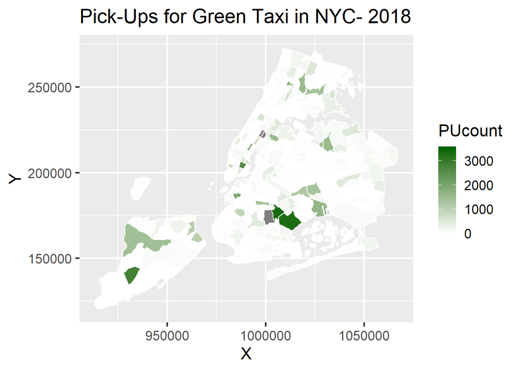

```r
lim = as.numeric(c("0","3500"))
map <- ggplot(data = ggplotdf1, aes(x = X, y = Y)) +
  geom_polygon(mapping = aes(group = group, fill = PUcount), color = "white") +
  scale_fill_gradient(low="white", high="darkgreen", limits = lim)+
  ggtitle("Pick-Ups for Green Taxi in NYC- 2018") +
   theme(plot.title = element_text(hjust = 0.5))+
  theme_gray(16)
map
```

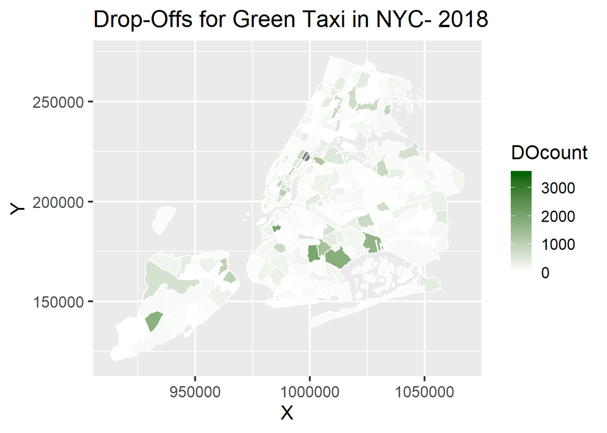

```r
map <- ggplot(data = ggplotdf1, aes(x = X, y = Y)) +
  geom_polygon(mapping = aes(group = group, fill = DOcount), color = "white") +
  scale_fill_gradient(low="white", high="darkgreen" , limits = lim)+
  ggtitle("Drop-Offs for Green Taxi in NYC- 2018") +
   theme(plot.title = element_text(hjust = 0.5))+
  theme_gray(16)
map
```

**V.Interactive Component**

https://fk2377.shinyapps.io/EDAV/

**VI.Conclusion**

The purpose of proposing green cabs for NYC per TLC reports was to increase mobility in outer boroughs of the city and improve safety and reduce illegal activities. Yellow cabs have about 95% of their pickups in Manhattan (below 96th Street) and the airports (JFK and LaGuardia). So the green cabs were designed to cover the rest of NYC. The data shows that has been the case mostly, with few exceptions. There are some pickups at JFK and east side of Manhattan by green cabs which defeats the purpose.

In addition, exploring the tip frequencies, there is a bimodal pattern for tipping in green cab riders. As about 30% of the riders do not tip and 35% of the riders tip about 20-25% of the fare. That is consistent with our observation of discussions in social media and news that there is no consensus about this topic.

Link to project repo: https://github.com/fk2377/EDAV_final